# Part I - Prosper Loan Data

## Multivariate Exploration

### Is there a relationship between Prosper Score and Debt to income ratio?

Prosper Ratings vs Debt to Income Ratio

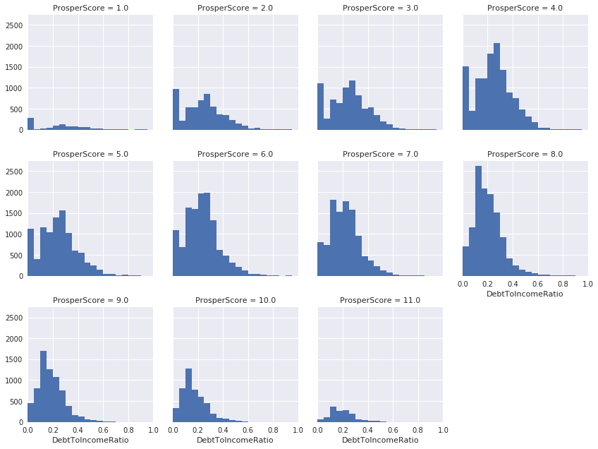

```python
from IPython.display import HTML, display
display(HTML('Prosper Ratings vs Debt to Income Ratio'))
bins = np.arange(0, 1, 0.05)
sb.set(rc = {'figure.figsize':(15,8)})
g = sb.FacetGrid(data = data, col = 'ProsperScore', margin_titles = True, col_wrap = 4)
g.map(plt.hist,'DebtToIncomeRatio', bins=bins)
plt.xlim(0,1)
plt.show()
```

### Observation

The distribution of the debt to income ration does not change significantly across the Prosper Scores. However, slightly more people with zeros income with the lower prosper scores.

### Is there a relationship between Income Range and Debt to income ratio?

Income Range vs Debt to Income Ratio

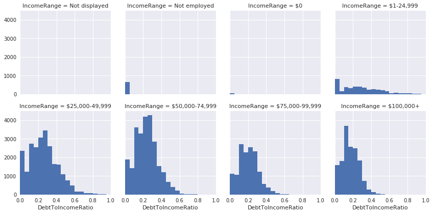

```python
display(HTML('Income Range vs Debt to Income Ratio'))
bins = np.arange(0, 1, 0.05)
sb.set(rc = {'figure.figsize':(15,8)})
g = sb.FacetGrid(data = data, col = 'IncomeRange', margin_titles = True, col_wrap = 4)
g.map(plt.hist,'DebtToIncomeRatio', bins=bins)
plt.xlim(0,1)
plt.show()
```

### Does Homeowner status have an influence on interest rates?

```python
#create a sample of the data, making it easier to plot a Scatter Plot
data_samp = data.sample(1000,replace = False)
```

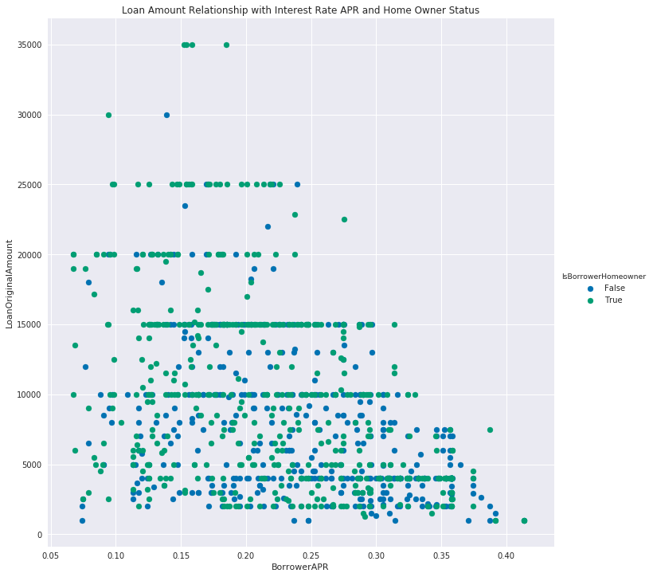

```python
plt.figure(figsize = [25, 25])
g = sb.FacetGrid(data = data_samp, hue = 'IsBorrowerHomeowner', size = 10, palette = 'colorblind')
g.map(plt.scatter, 'BorrowerAPR', 'LoanOriginalAmount')
plt.title('Loan Amount Relationship with Interest Rate APR and Home Owner Status')
g.add_legend()
```

### Observation

Being a home owner does not influence your relationship between Interest Rate APR and Loan Amount.

### Does being a homeowner influence loan amount and differ in the various income groups?

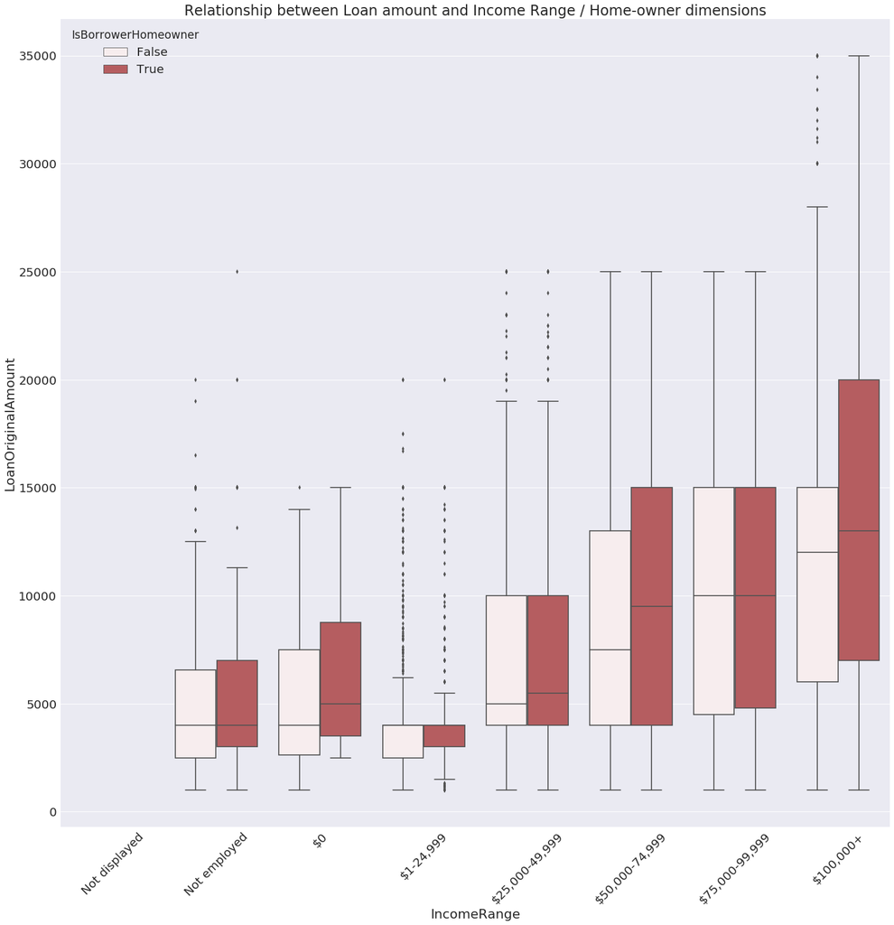

```python
base_color = sb.color_palette()[2]
plt.figure(figsize = [25, 25])
sb.set(font_scale = 2)
sb.boxplot(data = data, x = 'IncomeRange', y = 'LoanOriginalAmount',hue = 'IsBorrowerHomeowner' ,color = base_color)
plt.title('Relationship between Loan amount and Income Range / Home-owner dimensions')
plt.xticks(rotation = 45);
```

### Observation

Home owners tend to take out slightly higher loan amounts compared to people who are not home owners. People with an income also take out higher loan amounts.

### Overview

> I was surprised as I thought one would getter a better/lower interest rate if they were already a homeowner as they had collateral.

## Summary & Conclusions

### Summary

> Majority of the loans are for Debt Consolidations

> Interest Rates and Prosper Score follow a normal distribution.

> Most borrowers who take out a loan are employed.

> The Mode income range for borrowers is between $50k and $75k.

> There is a medium to strong positive relationship between Prosper Score and Interest rate APR. While, there is a medium negative relationship with loan amount and interest rate APR.

> Generally, the higher the prosper score (less risky), the higher the loan amount, however the more variable the loan amount range in the higher prosper scores.

> Debt to Income ratio slightly decreases with prosper score and there is less variation, the reltionship is weak and there is not evidence that it is an influencing factor.

> Employed borrowers tend to take out bigger loans (however more variation in the loan amounts), while employment status does not affect the Interest Rate APR unless one is not employed, then the interest rate skews towards a higher rate.

> Debt consolidation tends to have a lower interest rate (given the bigger loan amounts and all debt being in one place). While cosmetics and unknown loans tend to have slightly higher interest rates.

> Being a home owner does not affect your interest rate. Home owners do take out slightly higher loans than ones who do not own a house

### Limitations

> This analysis did not not involve significant testing and points are merely observations.

### Conclusion

> Not significant conclusions where found, significant testsing would be best to continue this analysis to better understand difference and multi linear regression to understand relationships with different variable.

> Additional variables should be introduced from the original dataset to explore and see if there are any additional influences on the prosper score and ultimately the interest rate.